# Village Random Effects: A Deep Dive into Hierarchical Models

Max Lang

2025-06-25

# Introduction: What are Hierarchical Models?

Hierarchical models, also known as multilevel models or mixed-effects models, are statistical models that account for data with a nested or grouped structure. In our example, mosquito abundance measurements are nested within villages.

## Alternative Modeling Approaches

Before diving into hierarchical models, let’s consider two extreme approaches to handling grouped data:

### 1. Complete Pooling: Ignoring the Grouping Structure

In this approach, we completely ignore that observations come from different villages and fit a single model:

$$y_{ij} = \beta_0 +
\varepsilon_{ij}$$

Where: - $y_{ij}$ is the $j$-th observation in village $i$ - $\beta_0$ represents a constant overall intercept - $\varepsilon_{ij} \sim N(0, \sigma^2)$ is the error term

The least squares estimator is simply:
$$\hat{\beta}_0 = \bar{y} =
\frac{1}{N}\sum_{i=1}^{n_{villages}}\sum_{j=1}^{n_i} y_{ij}$$

**Problems with complete pooling:** - Treats all observations as coming from a single homogeneous population - Ignores village-level variation - Underestimates uncertainty for village-specific predictions - Can lead to incorrect inferences about treatment effects

### 2. No Pooling: Complete Differentiation of Groups

At the other extreme, we could fit a separate model for each village:

$$y_{ij} = \eta_i +
\varepsilon_{ij}$$

Where: - $\eta_i$ represents the village-specific effect (treated as fixed) - Each village gets its own parameter

The least squares estimator for each village is:
$$\hat{\eta}_i = \bar{y}_i =
\frac{1}{n_i}\sum_{j=1}^{n_i} y_{ij}$$

**Problems with no pooling:** - Doesn’t borrow strength across villages - Can overfit, especially with small sample sizes per village - Treats villages as completely unrelated - Cannot make inferences about new villages

### 3. Partial Pooling: The Hierarchical Model Solution

Hierarchical models provide a middle ground through **partial pooling**:

$$y_{ij} = \mu_0 + u_i +
\varepsilon_{ij}$$

Where: - $u_i \sim N(0, \sigma^2_{village})$ is the random village effect - Villages are related through a common distribution

This approach: - Borrows strength across villages - Shrinks extreme estimates toward the grand mean - Provides a natural way to handle unbalanced data - Allows inference about the population of villages

## The Mathematical Framework of Hierarchical Models

## The Mathematical Framework

A two-level hierarchical model can be written as:

**Level 1 (Observation level):**
$$Y_{ij} | \mu_i \sim N(\mu_i,
\sigma^2_{within})$$

Where: - $Y_{ij}$ is the $j$-th observation in village $i$ - $\mu_i$ is the true mean for village $i$ - $\sigma^2_{within}$ is the within-village variance

**Level 2 (Village level):**
$$\mu_i \sim N(\mu_0,
\sigma^2_{village})$$

Where: - $\mu_0$ is the grand mean (population mean across all villages) - $\sigma^2_{village}$ is the between-village variance

## Combined Model

We can also write this as a single equation:
$$Y_{ij} = \mu_0 + u_i + \epsilon_{ij}$$

Where: - $u_i \sim N(0, \sigma^2_{village})$ is the random village effect - $\epsilon_{ij} \sim N(0, \sigma^2_{within})$ is the within-village error - $u_i$ and $\epsilon_{ij}$ are independent

## Variance Decomposition

The total variance in the data is:
$$Var(Y_{ij}) = \sigma^2_{village} +
\sigma^2_{within}$$

The **Intraclass Correlation Coefficient (ICC)** measures the proportion of variance due to villages:
$$ICC =
\frac{\sigma^2_{village}}{\sigma^2_{village} +
\sigma^2_{within}}$$

# Visualizing the Hierarchical Structure

## Basic Visualization

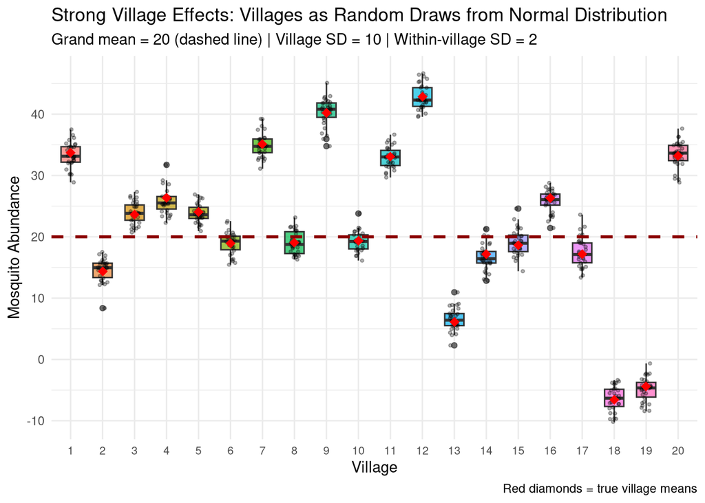

```r
# Step 7: Create the basic plot first
p_basic <- ggplot(data_strong_extended, aes(x = village, y = abundance)) +
  # Village boxplots
  geom_boxplot(aes(fill = village), alpha = 0.7, width = 0.6) +
  # Individual observations
  geom_jitter(width = 0.15, alpha = 0.3, size = 0.8) +
  # True village means
  geom_point(data = village_stats,
             aes(y = true_mean),
             color = "red",
             size = 3,
             shape = 18) +
  # Grand mean line
  geom_hline(yintercept = grand_mean,
             linetype = "dashed",
             color = "darkred",
             linewidth = 1) +
  scale_x_discrete(labels = function(x) gsub("V", "", x)) +
  theme_minimal() +
  theme(legend.position = "none",
        axis.text.x = element_text(size = 8)) +
  labs(title = "Strong Village Effects: Villages as Random Draws from Normal Distribution",
       subtitle = sprintf("Grand mean = %.0f (dashed line) | Village SD = %.0f | Within-village SD = %.0f",
                         grand_mean, village_sd, 2),
       x = "Village",
       y = "Mosquito Abundance",
       caption = "Red diamonds = true village means")

print(p_basic)
```

### What This Plot Shows:

1. **Between-village variation**: Notice how the red diamonds (true village means) vary substantially around the grand mean (dashed line). This variation follows $N(\mu_0, \sigma^2_{village}) = N(20, 10^2)$.
2. **Within-village variation**: Each boxplot shows the distribution within a village. The spread within each box is much smaller than the spread between village means, reflecting $\sigma_{within} = 2 << \sigma_{village} = 10$.
3. **Hierarchical structure**: Each observation belongs to two distributions:
   - First, its village mean is drawn from $N(20, 10^2)$
   - Then, the observation is drawn from $N(\mu_i, 2^2)$

## Enhanced Hierarchical Visualization

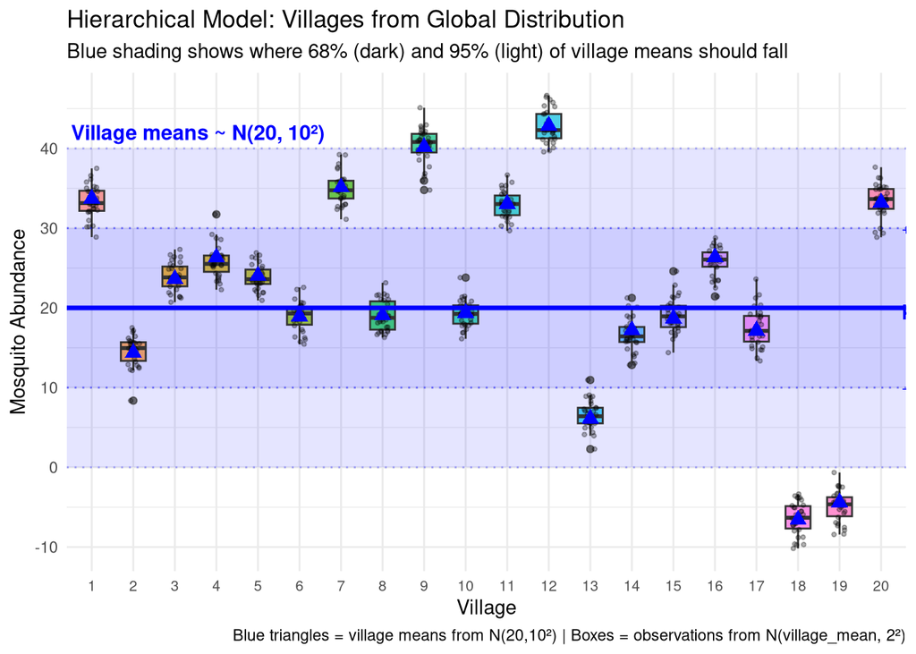

```r
# Step 8: Create enhanced plot showing the hierarchical structure
p_hierarchical <- ggplot(data_strong_extended, aes(x = village, y = abundance)) +

  # Add a visual representation of the population distribution of village means
  # This shows the N(20, 10) distribution that village means are drawn from
  annotate("rect",
           xmin = -Inf, xmax = Inf,
           ymin = grand_mean - 2*village_sd,
           ymax = grand_mean + 2*village_sd,
           alpha = 0.1, fill = "blue") +

  annotate("rect",
           xmin = -Inf, xmax = Inf,
           ymin = grand_mean - village_sd,
           ymax = grand_mean + village_sd,
           alpha = 0.1, fill = "blue") +

  # Village boxplots
  geom_boxplot(aes(fill = village), alpha = 0.7, width = 0.6) +

  # Individual observations
  geom_jitter(width = 0.15, alpha = 0.3, size = 0.8) +

  # True village means (these are draws from N(20, 10))
  geom_point(data = village_stats,
             aes(y = true_mean),
             color = "blue",
             size = 3,
             shape = 17) +  # Triangle for village means

  # Grand mean line (μ₀ = 20)
  geom_hline(yintercept = grand_mean,
             linetype = "solid",
             color = "blue",
             linewidth = 1.2) +

  # Add lines showing ±1 SD and ±2 SD from grand mean
  geom_hline(yintercept = grand_mean + village_sd,
             linetype = "dotted",
             color = "blue",
             alpha = 0.5) +
  geom_hline(yintercept = grand_mean - village_sd,
             linetype = "dotted",
             color = "blue",
             alpha = 0.5) +
  geom_hline(yintercept = grand_mean + 2*village_sd,
             linetype = "dotted",
             color = "blue",
             alpha = 0.3) +
  geom_hline(yintercept = grand_mean - 2*village_sd,
             linetype = "dotted",
             color = "blue",
             alpha = 0.3) +

  # Add text annotations
  annotate("text", x = 0.5, y = grand_mean + 2.2*village_sd,
           label = "Village means ~ N(20, 10²)",
           hjust = 0, color = "blue", fontface = "bold", size = 4) +

  annotate("text", x = 20.5, y = grand_mean,
           label = "μ₀",
           hjust = 0, color = "blue", fontface = "bold") +

  annotate("text", x = 20.5, y = grand_mean + village_sd,
           label = "+1σ",
           hjust = 0, color = "blue", size = 3) +

  annotate("text", x = 20.5, y = grand_mean - village_sd,
           label = "-1σ",
           hjust = 0, color = "blue", size = 3) +

  scale_x_discrete(labels = function(x) gsub("V", "", x)) +
  theme_minimal() +
  theme(legend.position = "none",
        axis.text.x = element_text(size = 8)) +
  labs(title = "Hierarchical Model: Villages from Global Distribution",
       subtitle = "Blue shading shows where 68% (dark) and 95% (light) of village means should fall",
       x = "Village",
       y = "Mosquito Abundance",
       caption = "Blue triangles = village means from N(20,10²) | Boxes = observations from N(village_mean, 2²)")

print(p_hierarchical)
```

### Mathematical Interpretation:

The blue shaded regions represent probability zones for village means: - **Dark blue (±1σ)**: Contains ~68% of village means, i.e., $P(\mu_0 - \sigma_{village} < \mu_i < \mu_0 + \sigma_{village}) \approx 0.68$ - **Light blue (±2σ)**: Contains ~95% of village means, i.e., $P(\mu_0 - 2\sigma_{village} < \mu_i < \mu_0 + 2\sigma_{village}) \approx 0.95$

## Side-by-Side Visualization: Population and Sample

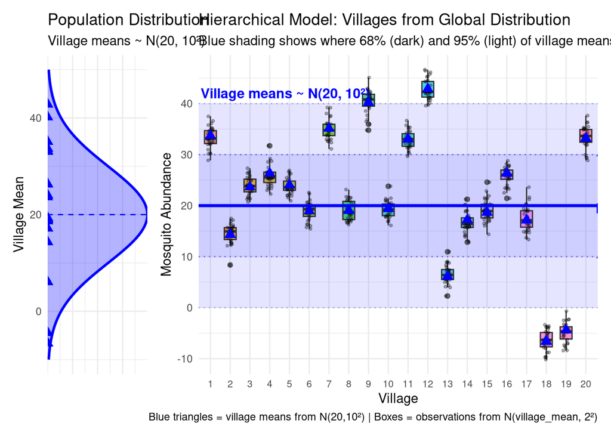

```r
# Step 9: Create a side-by-side visualization showing the concept more clearly
library(patchwork)

# Create density plot showing the population distribution
p_population <- ggplot() +
  stat_function(fun = dnorm,
                args = list(mean = grand_mean, sd = village_sd),
                xlim = c(grand_mean - 3*village_sd, grand_mean + 3*village_sd),
                geom = "area", fill = "blue", alpha = 0.3) +
  stat_function(fun = dnorm,
                args = list(mean = grand_mean, sd = village_sd),
                xlim = c(grand_mean - 3*village_sd, grand_mean + 3*village_sd),
                color = "blue", linewidth = 1) +
  # Add the actual village means as points
  geom_point(data = village_stats,
             aes(x = true_mean, y = 0),
             color = "blue", size = 3, shape = 17) +
  geom_vline(xintercept = grand_mean, color = "blue", linetype = "dashed") +
  scale_y_continuous(expand = c(0, 0)) +
  coord_flip(xlim = c(-10, 50)) +
  theme_minimal() +
  labs(title = "Population Distribution",
       subtitle = "Village means ~ N(20, 10²)",
       y = "", x = "Village Mean") +
  theme(axis.text.x = element_blank(),
        axis.ticks.x = element_blank())

# Combine with the main plot
p_combined <- p_population | p_hierarchical
p_combined <- p_combined + plot_layout(widths = c(1, 4))

print(p_combined)
```

```r
# Step 10: Verify the hierarchical structure with numbers
cat("\nVERIFYING THE HIERARCHICAL STRUCTURE\n")
```

```
##
## VERIFYING THE HIERARCHICAL STRUCTURE
```

```r
cat("=====================================\n")
cat(sprintf("Grand mean (μ₀): %.1f\n", grand_mean))
```

```
## Grand mean (μ₀): 20.0
```

```r
cat(sprintf("Village SD (σ_village): %.1f\n", village_sd))
```

```
## Village SD (σ_village): 10.0
```

```r
cat(sprintf("Within-village SD (σ_within): %.1f\n\n", 2))
```

```
## Within-village SD (σ_within): 2.0
```

```r
# Check if village means follow N(20, 10)
cat("Village means should be approximately N(20, 10):\n")
```

```
## Village means should be approximately N(20, 10):
```

```r
cat(sprintf("  Observed mean of village means: %.1f\n", mean(village_stats$true_mean)))
```

```
##   Observed mean of village means: 21.9
```

```r
cat(sprintf("  Observed SD of village means: %.1f\n", sd(village_stats$true_mean)))
```

```
##   Observed SD of village means: 13.1
```

```r
cat(sprintf("  Expected range (μ ± 2σ): [%.1f, %.1f]\n",
            grand_mean - 2*village_sd, grand_mean + 2*village_sd))
```

```
##   Expected range (μ ± 2σ): [0.0, 40.0]
```

```r
cat(sprintf("  Actual range: [%.1f, %.1f]\n",
            min(village_stats$true_mean), max(village_stats$true_mean)))
```

```
##   Actual range: [-6.6, 42.9]
```

## Visualization with Theoretical Distributions

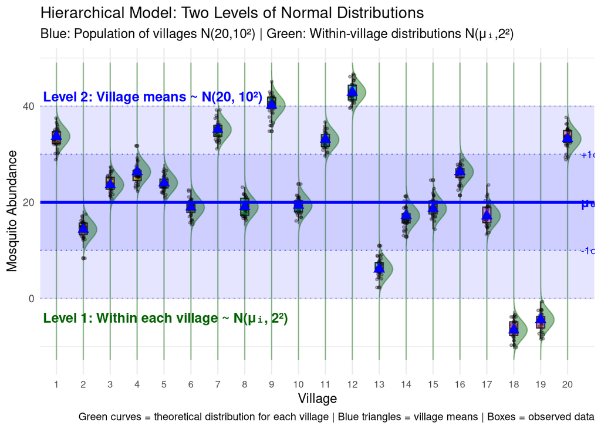

```r
# Step 8: Create enhanced plot with halfeye distributions for each village
library(ggdist)
library(distributional)

# First, let's create a proper dataset for the halfeye distributions
# We need to specify the distribution parameters for each village
village_dist_data <- village_stats %>%
  mutate(
    # Create a dummy y variable for positioning
    y = true_mean,
    # Specify the distribution for each village
    dist = dist_normal(true_mean, 2)  # mean = village mean, sd = 2
  )

p_hierarchical_with_halfeye <- ggplot(data_strong_extended, aes(x = village, y = abundance)) +

  # Add a visual representation of the population distribution of village means
  # This shows the N(20, 10) distribution that village means are drawn from
  annotate("rect",
           xmin = -Inf, xmax = Inf,
           ymin = grand_mean - 2*village_sd,
           ymax = grand_mean + 2*village_sd,
           alpha = 0.1, fill = "blue") +

  annotate("rect",
           xmin = -Inf, xmax = Inf,
           ymin = grand_mean - village_sd,
           ymax = grand_mean + village_sd,
           alpha = 0.1, fill = "blue") +

  # Add halfeye for each village's theoretical distribution
  # Use a separate data source for this layer
  stat_dist_halfeye(
    data = village_dist_data,
    aes(x = village,
        y = y,  # Use the dummy y variable
        dist = dist),
    alpha = 0.4,
    fill = "darkgreen",
    slab_color = "darkgreen",
    slab_linewidth = 0.5,
    scale = 0.5,  # Adjust width of distributions
    inherit.aes = FALSE  # Don't inherit aesthetics from main plot
  ) +

  # Village boxplots
  geom_boxplot(aes(fill = village),
               alpha = 0.7,
               width = 0.3,  # Make narrower so halfeye is visible
               outlier.size = 1) +

  # Individual observations
  geom_jitter(width = 0.1, alpha = 0.3, size = 0.8) +

  # True village means (these are draws from N(20, 10))
  geom_point(data = village_stats,
             aes(y = true_mean, x= village),
             color = "blue",
             size = 3,
             shape = 17,
             inherit.aes = FALSE) +  # Triangle for village means

  # Grand mean line (μ₀ = 20)
  geom_hline(yintercept = grand_mean,
             linetype = "solid",
             color = "blue",
             linewidth = 1.2) +

  # Add lines showing ±1 SD and ±2 SD from grand mean
  geom_hline(yintercept = grand_mean + village_sd,
             linetype = "dotted",
             color = "blue",
             alpha = 0.5) +
  geom_hline(yintercept = grand_mean - village_sd,
             linetype = "dotted",
             color = "blue",
             alpha = 0.5) +
  geom_hline(yintercept = grand_mean + 2*village_sd,
             linetype = "dotted",
             color = "blue",
             alpha = 0.3) +
  geom_hline(yintercept = grand_mean - 2*village_sd,
             linetype = "dotted",
             color = "blue",
             alpha = 0.3) +

  # Add text annotations
  annotate("text", x = 0.5, y = grand_mean + 2.2*village_sd,
           label = "Level 2: Village means ~ N(20, 10²)",
           hjust = 0, color = "blue", fontface = "bold", size = 4) +

  annotate("text", x = 0.5, y = grand_mean - 2.4*village_sd,
           label = "Level 1: Within each village ~ N(μᵢ, 2²)",
           hjust = 0, color = "darkgreen", fontface = "bold", size = 4) +

  annotate("text", x = 20.5, y = grand_mean,
           label = "μ₀",
           hjust = 0, color = "blue", fontface = "bold") +

  annotate("text", x = 20.5, y = grand_mean + village_sd,
           label = "+1σ",
           hjust = 0, color = "blue", size = 3) +

  annotate("text", x = 20.5, y = grand_mean - village_sd,
           label = "-1σ",
           hjust = 0, color = "blue", size = 3) +

  scale_x_discrete(labels = function(x) gsub("V", "", x)) +
  theme_minimal() +
  theme(legend.position = "none",
        axis.text.x = element_text(size = 8)) +
  labs(title = "Hierarchical Model: Two Levels of Normal Distributions",
       subtitle = "Blue: Population of villages N(20,10²) | Green: Within-village distributions N(μᵢ,2²)",
       x = "Village",
       y = "Mosquito Abundance",
       caption = "Green curves = theoretical distribution for each village | Blue triangles = village means | Boxes = observed data")

print(p_hierarchical_with_halfeye)
```

### Understanding the Two-Level Structure:

The green distributions show the **conditional distribution** of observations given the village:
$$Y_{ij} | \mu_i \sim N(\mu_i, 2^2)$$

Each green curve is centered at its village’s true mean (blue triangle), which itself was drawn from:
$$\mu_i \sim N(20, 10^2)$$

## Combined Visualization

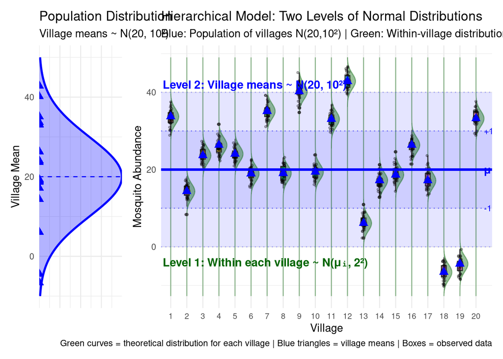

```r
# Combine with the main plot
p_combined <- p_population | p_hierarchical_with_halfeye
p_combined <- p_combined + plot_layout(widths = c(1, 4))

print(p_combined)
```

# Formal Mathematical Assumptions

```r
cat("\nFORMAL ASSUMPTIONS FOR RANDOM EFFECTS MODEL\n")
```

```
##
## FORMAL ASSUMPTIONS FOR RANDOM EFFECTS MODEL
```

```r
cat("===========================================\n\n")
cat("1. LEVEL 2 ASSUMPTION (Village Level):\n")
```

```
## 1. LEVEL 2 ASSUMPTION (Village Level):
```

```r
cat("   - Village means (μᵢ) are normally distributed\n")
```

```
##    - Village means (μᵢ) are normally distributed
```

```r
cat("   - μᵢ ~ N(μ₀, σ²ᵥᵢₗₗₐ𝓰ₑ)\n")
```

```
##    - μᵢ ~ N(μ₀, σ²ᵥᵢₗₗₐ𝓰ₑ)
```

```r
cat("   - This means village effects are exchangeable\n")
```

```
##    - This means village effects are exchangeable
```

```r
cat("   - Check: Q-Q plot of village means, Shapiro-Wilk test\n\n")
```

```
##    - Check: Q-Q plot of village means, Shapiro-Wilk test
```

```r
cat("2. LEVEL 1 ASSUMPTION (Observation Level):\n")
```

```
## 2. LEVEL 1 ASSUMPTION (Observation Level):
```

```r
cat("   - Within each village, observations are normally distributed\n")
```

```
##    - Within each village, observations are normally distributed
```

```r
cat("   - Yᵢⱼ|μᵢ ~ N(μᵢ, σ²ᵥᵥᵢₜₕᵢₙ)\n")
```

```
##    - Yᵢⱼ|μᵢ ~ N(μᵢ, σ²ᵥᵥᵢₜₕᵢₙ)
```

```r
cat("   - Variance is constant across villages (homoscedasticity)\n")
```

```
##    - Variance is constant across villages (homoscedasticity)
```

```r
cat("   - Check: Histograms by village, residual plots\n\n")
```

```
##    - Check: Histograms by village, residual plots
```

```r
cat("3. INDEPENDENCE ASSUMPTIONS:\n")
```

```
## 3. INDEPENDENCE ASSUMPTIONS:
```

```r
cat("   - Villages are independent of each other\n")
```

```
##    - Villages are independent of each other
```

```r
cat("   - Observations within villages are conditionally independent\n")
```

```
##    - Observations within villages are conditionally independent
```

```r
cat("   - No spatial or temporal correlation between villages\n\n")
```

```
##    - No spatial or temporal correlation between villages
```

# Model Fitting and Assumption Verification

## Fitting the Random Effects Model

When we fit a random effects model using `lmer`, we’re estimating:

$$Y_{ij} = \beta_0 + u_i +
\epsilon_{ij}$$

Where: - $\beta_0$ estimates $\mu_0$ (fixed effect) - $u_i \sim N(0, \sigma^2_{village})$ (random effect) - $\epsilon_{ij} \sim N(0, \sigma^2_{within})$ (residual)

The model estimates: - $\hat{\beta}_0$ (estimated grand mean) - $\hat{\sigma}^2_{village}$ (estimated between-village variance) - $\hat{\sigma}^2_{within}$ (estimated within-village variance)

# Village Level Assumptions

```r
# SECTION: VERIFYING RANDOM EFFECTS ASSUMPTIONS
# =============================================

cat("\n=== STEP-BY-STEP GUIDE TO VERIFYING RANDOM EFFECTS ASSUMPTIONS ===\n\n")
```

```
##
## === STEP-BY-STEP GUIDE TO VERIFYING RANDOM EFFECTS ASSUMPTIONS ===
```

```r
# First, fit the random effects model
model <- lmer(abundance ~ 1 + (1|village), data = data_strong_extended)

# Display model summary
summary(model)
```

```
## Linear mixed model fit by REML ['lmerMod']
## Formula: abundance ~ 1 + (1 | village)
##    Data: data_strong_extended
##
## REML criterion at convergence: 2651.4
##
## Scaled residuals:
##     Min      1Q  Median      3Q     Max
## -3.1666 -0.6401  0.0090  0.6663  3.1219
##
## Random effects:
##  Groups   Name        Variance Std.Dev.
##  village  (Intercept) 171.468  13.095
##  Residual               3.856   1.964
## Number of obs: 600, groups:  village, 20
##
## Fixed effects:
##             Estimate Std. Error t value
## (Intercept)   21.869      2.929   7.466
```

```r
# Extract variance components
var_components <- as.data.frame(VarCorr(model))
sigma_village_est <- sqrt(var_components[1, "vcov"])
sigma_within_est <- sqrt(var_components[2, "vcov"])

cat("\nESTIMATED VARIANCE COMPONENTS:\n")
```

```
##
## ESTIMATED VARIANCE COMPONENTS:
```

```r
cat(sprintf("σ̂_village = %.2f (true = %.0f)\n", sigma_village_est, village_sd))
```

```
## σ̂_village = 13.09 (true = 10)
```

```r
cat(sprintf("σ̂_within = %.2f (true = %.0f)\n", sigma_within_est, 2))
```

```
## σ̂_within = 1.96 (true = 2)
```

```r
cat(sprintf("Estimated ICC = %.3f (true = %.3f)\n",
            sigma_village_est^2 / (sigma_village_est^2 + sigma_within_est^2), ICC_true))
```

```
## Estimated ICC = 0.978 (true = 0.962)
```

```r
# Extract the random effects (BLUPs)
ranef_village <- ranef(model)$village
names(ranef_village) <- "village_effect"
ranef_village$village <- rownames(ranef_village)

# Also get the fitted village means
village_means_fitted <- coef(model)$village
names(village_means_fitted) <- "fitted_mean"
village_means_fitted$village <- rownames(village_means_fitted)

# Combine with observed means
verification_data <- village_stats %>%
  left_join(ranef_village, by = "village") %>%
  left_join(village_means_fitted, by = "village")

# ============================================
# STEP 1: VERIFY LEVEL 2 ASSUMPTION
# Village means are normally distributed
# ============================================

cat("\nSTEP 1: VERIFYING LEVEL 2 ASSUMPTION - Village Means ~ Normal\n")
```

```
##
## STEP 1: VERIFYING LEVEL 2 ASSUMPTION - Village Means ~ Normal
```

```r
cat("===========================================================\n\n")
# Mathematical explanation
cat("We're checking if: μᵢ ~ N(μ₀, σ²_village)\n")
```

```
## We're checking if: μᵢ ~ N(μ₀, σ²_village)
```

```r
cat("Equivalently: (μᵢ - μ₀)/σ_village ~ N(0, 1)\n\n")
```

```
## Equivalently: (μᵢ - μ₀)/σ_village ~ N(0, 1)
```

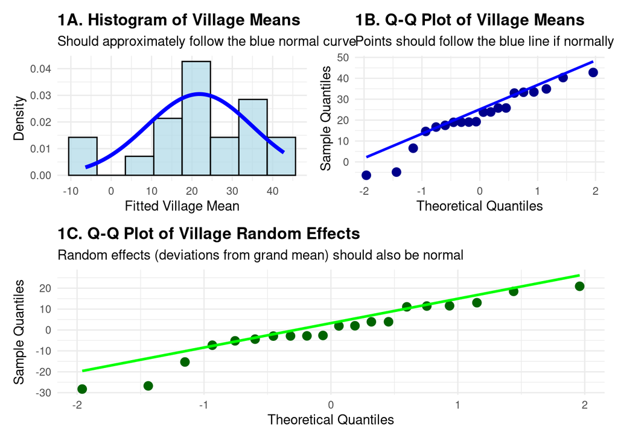

```r
# 1A. Visual Check: Histogram with normal overlay
p1a_histogram <- ggplot(verification_data, aes(x = fitted_mean)) +
  geom_histogram(aes(y = after_stat(density)),
                 bins = 8,
                 fill = "lightblue",
                 color = "black",
                 alpha = 0.7) +
  stat_function(fun = dnorm,
                args = list(mean = mean(verification_data$fitted_mean),
                           sd = sd(verification_data$fitted_mean)),
                color = "blue",
                linewidth = 1.5) +
  theme_minimal() +
  labs(title = "1A. Histogram of Village Means",
       subtitle = "Should approximately follow the blue normal curve",
       x = "Fitted Village Mean",
       y = "Density") +
  theme(plot.title = element_text(face = "bold"))

# 1B. Q-Q Plot - Most important visual check
p1b_qq <- ggplot(verification_data, aes(sample = fitted_mean)) +
  stat_qq(size = 3, color = "darkblue") +
  stat_qq_line(color = "blue", linewidth = 1) +
  theme_minimal() +
  labs(title = "1B. Q-Q Plot of Village Means",
       subtitle = "Points should follow the blue line if normally distributed",
       x = "Theoretical Quantiles",
       y = "Sample Quantiles") +
  theme(plot.title = element_text(face = "bold"))

# 1C. Alternative: Q-Q plot of random effects
p1c_qq_effects <- ggplot(verification_data, aes(sample = village_effect)) +
  stat_qq(size = 3, color = "darkgreen") +
  stat_qq_line(color = "green", linewidth = 1) +
  theme_minimal() +
  labs(title = "1C. Q-Q Plot of Village Random Effects",
       subtitle = "Random effects (deviations from grand mean) should also be normal",
       x = "Theoretical Quantiles",
       y = "Sample Quantiles") +
  theme(plot.title = element_text(face = "bold"))

# Combine visual diagnostics
library(patchwork)
p_level2_visual <- (p1a_histogram | p1b_qq) / (p1c_qq_effects)
print(p_level2_visual)
```

```r
# Formal statistical test
shapiro_test <- shapiro.test(verification_data$fitted_mean)
cat("\nShapiro-Wilk test for normality of village means:\n")
```

```
##
## Shapiro-Wilk test for normality of village means:
```

```r
cat(sprintf("W = %.4f, p-value = %.4f\n", shapiro_test$statistic, shapiro_test$p.value))
```

```
## W = 0.9405, p-value = 0.2450
```

```r
cat("If p > 0.05, we fail to reject the null hypothesis of normality\n")
```

```
## If p > 0.05, we fail to reject the null hypothesis of normality
```

### Interpreting Level 2 Diagnostics:

**Q-Q Plot Interpretation:** - Points on the line → Normal distribution confirmed - S-shaped curve → Heavy or light tails - Systematic deviation → Non-normality

**What if Level 2 assumption fails?** - Consider transformation of response variable - Use robust methods (e.g., t-distribution for random effects) - Check for outlier villages

# Observation (Statistical Unit) Level Assumption

```r
# ============================================
# STEP 2: VERIFY LEVEL 1 ASSUMPTIONS
# Within-village normality and homoscedasticity
# ============================================

cat("\nSTEP 2: VERIFYING LEVEL 1 ASSUMPTIONS - Within-Village Normality & Equal Variance\n")
```

```
##
## STEP 2: VERIFYING LEVEL 1 ASSUMPTIONS - Within-Village Normality & Equal Variance
```

```r
cat("================================================================================\n\n")
cat("Mathematical framework:\n")
```

```
## Mathematical framework:
```

```r
cat("Yᵢⱼ | μᵢ ~ N(μᵢ, σ²_within)\n")
```

```
## Yᵢⱼ | μᵢ ~ N(μᵢ, σ²_within)
```

```r
cat("This implies: εᵢⱼ = Yᵢⱼ - μᵢ ~ N(0, σ²_within)\n")
```

```
## This implies: εᵢⱼ = Yᵢⱼ - μᵢ ~ N(0, σ²_within)
```

```r
cat("Key: σ²_within should be the same for all villages (homoscedasticity)\n\n")
```

```
## Key: σ²_within should be the same for all villages (homoscedasticity)
```

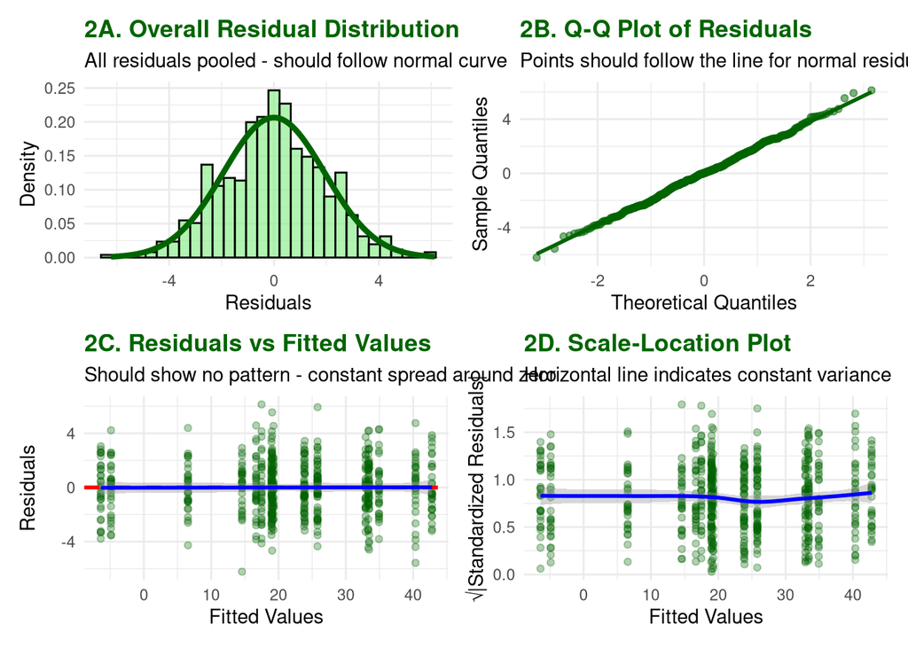

```r
# Extract residuals and fitted values from the model
data_strong_extended$residuals <- residuals(model)
data_strong_extended$fitted <- fitted(model)
data_strong_extended$standardized_residuals <- data_strong_extended$residuals / sd(data_strong_extended$residuals)

# 2A. Overall residual distribution
p2a_overall_residuals <- ggplot(data_strong_extended, aes(x = residuals)) +
  geom_histogram(aes(y = after_stat(density)),
                 bins = 30,
                 fill = "lightgreen",
                 color = "black",
                 alpha = 0.7) +
  stat_function(fun = dnorm,
                args = list(mean = 0, sd = sd(data_strong_extended$residuals)),
                color = "darkgreen",
                linewidth = 1.5) +
  theme_minimal() +
  labs(title = "2A. Overall Residual Distribution",
       subtitle = "All residuals pooled - should follow normal curve",
       x = "Residuals",
       y = "Density") +
  theme(plot.title = element_text(face = "bold", color = "darkgreen"))

# 2B. Q-Q plot of overall residuals
p2b_qq_residuals <- ggplot(data_strong_extended, aes(sample = residuals)) +
  stat_qq(alpha = 0.5, color = "darkgreen") +
  stat_qq_line(color = "darkgreen", linewidth = 1) +
  theme_minimal() +
  labs(title = "2B. Q-Q Plot of Residuals",
       subtitle = "Points should follow the line for normal residuals",
       x = "Theoretical Quantiles",
       y = "Sample Quantiles") +
  theme(plot.title = element_text(face = "bold", color = "darkgreen"))

# 2C. Residuals vs Fitted Values (check homoscedasticity)
p2c_resid_fitted <- ggplot(data_strong_extended, aes(x = fitted, y = residuals)) +
  geom_point(alpha = 0.3, color = "darkgreen") +
  geom_hline(yintercept = 0, color = "red", linetype = "dashed", linewidth = 1) +
  geom_smooth(method = "loess", se = TRUE, color = "blue", linewidth = 1) +
  theme_minimal() +
  labs(title = "2C. Residuals vs Fitted Values",
       subtitle = "Should show no pattern - constant spread around zero",
       x = "Fitted Values",
       y = "Residuals") +
  theme(plot.title = element_text(face = "bold", color = "darkgreen"))

# 2D. Scale-Location plot (check homoscedasticity)
p2d_scale_location <- ggplot(data_strong_extended,
                             aes(x = fitted, y = sqrt(abs(standardized_residuals)))) +
  geom_point(alpha = 0.3, color = "darkgreen") +
  geom_smooth(method = "loess", se = TRUE, color = "blue", linewidth = 1) +
  theme_minimal() +
  labs(title = "2D. Scale-Location Plot",
       subtitle = "Horizontal line indicates constant variance",
       x = "Fitted Values",
       y = "√|Standardized Residuals|") +
  theme(plot.title = element_text(face = "bold", color = "darkgreen"))

# Combine first set of plots
p_level1_overall <- (p2a_overall_residuals | p2b_qq_residuals) /
                    (p2c_resid_fitted | p2d_scale_location)
print(p_level1_overall)
```

### Homoscedasticity Test

```r
# Test for homoscedasticity using Levene's test
library(car)
levene_test <- leveneTest(residuals ~ village, data = data_strong_extended)
cat("\nLevene's Test for Homogeneity of Variance:\n")
```

```
##
## Levene's Test for Homogeneity of Variance:
```

```r
print(levene_test)
```

```
## Levene's Test for Homogeneity of Variance (center = median)
##        Df F value Pr(>F)
## group  19  0.5347 0.9473
##       580
```

```r
cat("\nIf p > 0.05, we fail to reject the null hypothesis of equal variances\n")
```

```
##
## If p > 0.05, we fail to reject the null hypothesis of equal variances
```

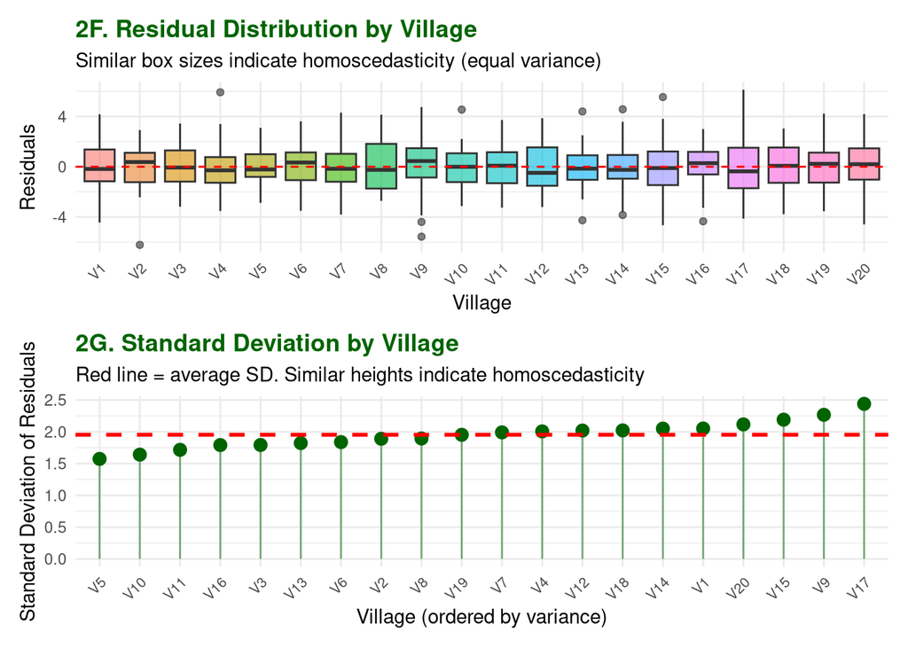

```r
# 2F. Residuals by village (boxplots)
p2f_residuals_by_village <- ggplot(data_strong_extended,
                                   aes(x = village, y = residuals, fill = village)) +
  geom_boxplot(alpha = 0.6) +
  geom_hline(yintercept = 0, color = "red", linetype = "dashed") +
  theme_minimal() +
  theme(legend.position = "none",
        axis.text.x = element_text(angle = 45, hjust = 1, size = 8)) +
  labs(title = "2F. Residual Distribution by Village",
       subtitle = "Similar box sizes indicate homoscedasticity (equal variance)",
       x = "Village",
       y = "Residuals") +
  theme(plot.title = element_text(face = "bold", color = "darkgreen"))

# 2G. Variance by village (visual comparison)
village_variance <- data_strong_extended %>%
  group_by(village) %>%
  summarise(
    variance = var(residuals),
    sd = sd(residuals),
    n = n()
  ) %>%
  arrange(variance)

p2g_variance_comparison <- ggplot(village_variance,
                                  aes(x = reorder(village, variance), y = sd)) +
  geom_point(size = 3, color = "darkgreen") +
  geom_segment(aes(xend = village, yend = 0), color = "darkgreen", alpha = 0.5) +
  geom_hline(yintercept = mean(village_variance$sd),
             color = "red", linetype = "dashed", linewidth = 1) +
  theme_minimal() +
  theme(axis.text.x = element_text(angle = 45, hjust = 1, size = 8)) +
  labs(title = "2G. Standard Deviation by Village",
       subtitle = "Red line = average SD. Similar heights indicate homoscedasticity",
       x = "Village (ordered by variance)",
       y = "Standard Deviation of Residuals") +
  theme(plot.title = element_text(face = "bold", color = "darkgreen"))

# Combine variance plots
p_level1_variance <- p2f_residuals_by_village / p2g_variance_comparison
print(p_level1_variance)
```

```r
# Calculate variance ratio
var_ratio <- max(village_variance$variance) / min(village_variance$variance)
cat(sprintf("\nVariance ratio (max/min): %.2f\n", var_ratio))
```

```
##
## Variance ratio (max/min): 2.40
```

```r
cat("Rule of thumb: ratio < 3 suggests reasonable homoscedasticity\n")
```

```
## Rule of thumb: ratio < 3 suggests reasonable homoscedasticity
```

# Independence Assumptions

## Mathematical Framework for Independence

Independence in hierarchical models has three components:

1. **Between-village independence**: $Cov(u_i, u_j) = 0$ for $i \neq j$
2. **Within-village conditional independence**: $Cov(\epsilon_{ij}, \epsilon_{ik} | u_i) = 0$ for $j \neq k$
3. **Cross-level independence**: $Cov(u_i, \epsilon_{jk}) = 0$ for all $i, j, k$

```r
# ============================================
# STEP 3: VERIFY INDEPENDENCE ASSUMPTIONS
# ============================================

cat("\nSTEP 3: VERIFYING INDEPENDENCE ASSUMPTIONS\n")
```

```
##
## STEP 3: VERIFYING INDEPENDENCE ASSUMPTIONS
```

```r
cat("==========================================\n\n")
cat("Mathematical requirements:\n")
```

```
## Mathematical requirements:
```

```r
cat("1. Cov(uᵢ, uⱼ) = 0 for i ≠ j (villages independent)\n")
```

```
## 1. Cov(uᵢ, uⱼ) = 0 for i ≠ j (villages independent)
```

```r
cat("2. Cov(εᵢⱼ, εᵢₖ | uᵢ) = 0 for j ≠ k (observations independent within village)\n")
```

```
## 2. Cov(εᵢⱼ, εᵢₖ | uᵢ) = 0 for j ≠ k (observations independent within village)
```

```r
cat("3. Cov(uᵢ, εⱼₖ) = 0 (random effects independent of residuals)\n\n")
```

```
## 3. Cov(uᵢ, εⱼₖ) = 0 (random effects independent of residuals)
```

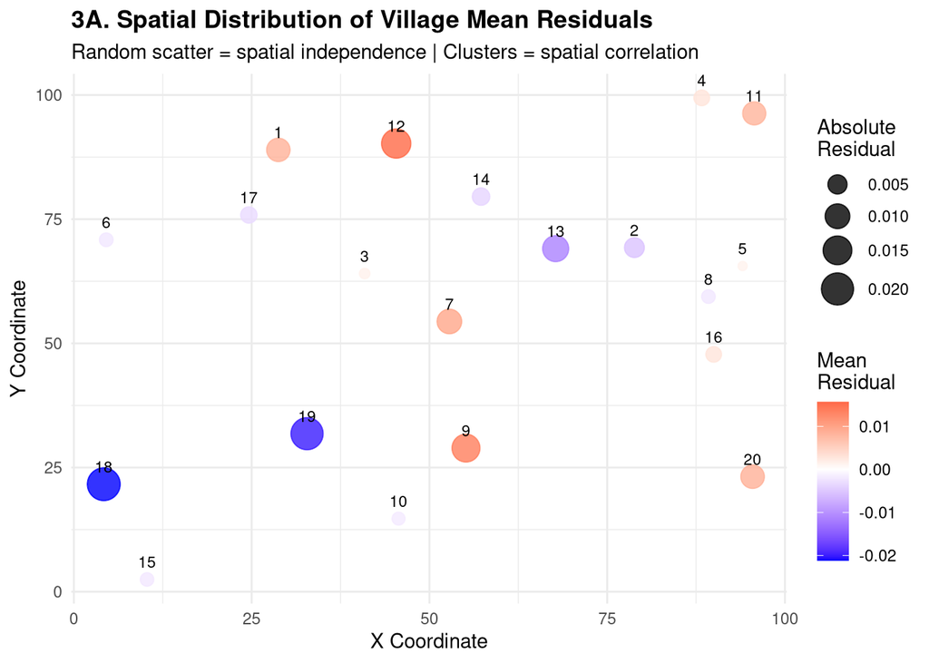

```r
# First, let's add some spatial/temporal information to our data for demonstration
# In real data, you would have actual coordinates or time stamps
set.seed(123)
village_info <- data.frame(
  village = unique(data_strong_extended$village),
  # Simulated spatial coordinates
  x_coord = runif(length(unique(data_strong_extended$village)), 0, 100),
  y_coord = runif(length(unique(data_strong_extended$village)), 0, 100),
  # Simulated collection order/time
  collection_order = sample(1:length(unique(data_strong_extended$village)))
)

# Add this info to our data
data_with_location <- data_strong_extended %>%
  left_join(village_info, by = "village") %>%
  arrange(collection_order) %>%
  mutate(observation_order = 1:n())

# Get village-level summaries with spatial info
village_summary <- data_with_location %>%
  group_by(village, x_coord, y_coord, collection_order) %>%
  summarise(
    mean_abundance = mean(abundance),
    mean_residual = mean(residuals),
    .groups = "drop"
  )

# 3A. SPATIAL INDEPENDENCE - Check for spatial autocorrelation
# Calculate distance matrix
dist_matrix <- as.matrix(dist(village_summary[, c("x_coord", "y_coord")]))

# Create a spatial plot of residuals
p3a_spatial <- ggplot(village_summary, aes(x = x_coord, y = y_coord)) +
  geom_point(aes(color = mean_residual, size = abs(mean_residual)), alpha = 0.8) +
  scale_color_gradient2(low = "blue", mid = "white", high = "red", midpoint = 0) +
  scale_size_continuous(range = c(2, 8)) +
  geom_text(aes(label = gsub("V", "", village)), size = 3, vjust = -1) +
  theme_minimal() +
  labs(title = "3A. Spatial Distribution of Village Mean Residuals",
       subtitle = "Random scatter = spatial independence | Clusters = spatial correlation",
       x = "X Coordinate",
       y = "Y Coordinate",
       color = "Mean\nResidual",
       size = "Absolute\nResidual") +
  theme(plot.title = element_text(face = "bold"))

print(p3a_spatial)
```

## Moran’s I Test for Spatial Autocorrelation

Moran’s I statistic tests for spatial autocorrelation:

$$I = \frac{n}{\sum_{i}\sum_{j}w_{ij}}
\frac{\sum_{i}\sum_{j}w_{ij}(y_i - \bar{y})(y_j - \bar{y})}{\sum_{i}(y_i
- \bar{y})^2}$$

Where: - $w_{ij}$ is the spatial weight between villages $i$ and $j$ - $y_i$ is the residual for village $i$ - $\bar{y}$ is the mean residual

```r
# Calculate Moran's I
# Create spatial weights matrix (inverse distance)
W <- 1/dist_matrix
diag(W) <- 0
W <- W/rowSums(W)  # Row-standardize

# Calculate Moran's I manually
n <- nrow(village_summary)
y <- village_summary$mean_residual
y_mean <- mean(y)
y_centered <- y - y_mean

# Numerator
numerator <- sum(W * outer(y_centered, y_centered))
# Denominator
denominator <- sum(y_centered^2)
# Moran's I
morans_i <- (n / sum(W)) * (numerator / denominator)

cat(sprintf("\nMoran's I statistic: %.4f\n", morans_i))
```

```
##
## Moran's I statistic: -0.0184
```

```r
cat("Expected value under null hypothesis (no spatial correlation): ")
```

```
## Expected value under null hypothesis (no spatial correlation):
```

```r
cat(sprintf("E[I] = -1/(n-1) = %.4f\n", -1/(n-1)))
```

```
## E[I] = -1/(n-1) = -0.0526
```

```r
cat("Values near 0 indicate no spatial autocorrelation\n")
```

```
## Values near 0 indicate no spatial autocorrelation
```

```r
cat("Positive values indicate positive spatial autocorrelation\n")
```

```
## Positive values indicate positive spatial autocorrelation
```

```r
cat("Negative values indicate negative spatial autocorrelation\n")
```

```
## Negative values indicate negative spatial autocorrelation
```

[figure not shown]

```r
# 3E. Moran scatterplot
spatial_lag <- as.vector(W %*% y)
moran_data <- data.frame(
  residual = y_centered,
  spatial_lag = spatial_lag - y_mean,
  village = village_summary$village
)

p3e_moran <- ggplot(moran_data, aes(x = residual, y = spatial_lag)) +
  geom_hline(yintercept = 0, color = "gray50", linetype = "dashed") +
  geom_vline(xintercept = 0, color = "gray50", linetype = "dashed") +
  geom_point(size = 3, alpha = 0.7) +
  geom_smooth(method = "lm", color = "red", se = TRUE) +
  geom_text(aes(label = gsub("V", "", village)), size = 2, vjust = -1) +
  annotate("text", x = min(moran_data$residual), y = max(moran_data$spatial_lag),
           label = "High-High\n(Clustering)", hjust = 0, vjust = 1, color = "red") +
  annotate("text", x = max(moran_data$residual), y = min(moran_data$spatial_lag),
           label = "Low-Low\n(Clustering)", hjust = 1, vjust = 0, color = "red") +
  theme_minimal() +
  labs(title = "3E. Moran's I Scatterplot",
       subtitle = sprintf("Moran's I = %.3f | Slope = spatial autocorrelation", morans_i),
       x = "Village Residual (centered)",
       y = "Spatial Lag of Residual") +
  theme(plot.title = element_text(face = "bold"))

print(p3e_moran)
```

## Temporal Independence and ACF

The autocorrelation function (ACF) at lag $k$ is:

$$\rho_k = \frac{\sum_{t=1}^{n-k}(y_t -
\bar{y})(y_{t+k} - \bar{y})}{\sum_{t=1}^{n}(y_t -
\bar{y})^2}$$

Under independence, $\rho_k \approx 0$ for all $k > 0$.

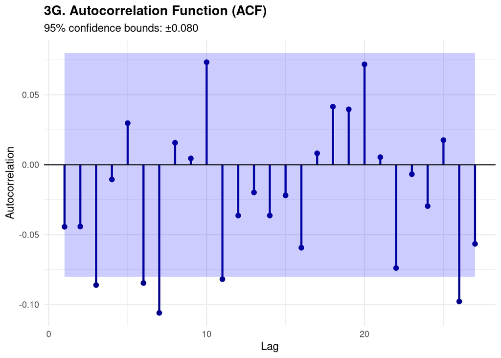

```r
# 3G. ACF plot for overall temporal correlation
acf_data <- acf(data_with_location$residuals, plot = FALSE)
acf_df <- data.frame(
  lag = acf_data$lag[-1],  # Remove lag 0
  acf = acf_data$acf[-1]
)

# Calculate confidence bounds
conf_bound <- qnorm(0.975)/sqrt(length(data_with_location$residuals))

p3g_acf <- ggplot(acf_df, aes(x = lag, y = acf)) +
  geom_segment(aes(xend = lag, yend = 0), color = "darkblue", linewidth = 1) +
  geom_point(color = "darkblue", size = 2) +
  geom_ribbon(aes(ymin = -conf_bound, ymax = conf_bound),
              alpha = 0.2, fill = "blue") +
  geom_hline(yintercept = 0, color = "black") +
  theme_minimal() +
  labs(title = "3G. Autocorrelation Function (ACF)",
       subtitle = sprintf("95%% confidence bounds: ±%.3f", conf_bound),
       x = "Lag",
       y = "Autocorrelation") +
  theme(plot.title = element_text(face = "bold"))

print(p3g_acf)
```

```r
cat("\nINDEPENDENCE DIAGNOSTICS SUMMARY:\n")
```

```
##
## INDEPENDENCE DIAGNOSTICS SUMMARY:
```

```r
cat("==================================\n\n")
cat("If assumptions are met:\n")
```

```
## If assumptions are met:
```

```r
cat("✓ Moran's I ≈ 0 (no spatial autocorrelation)\n")
```

```
## ✓ Moran's I ≈ 0 (no spatial autocorrelation)
```

```r
cat("✓ ACF values within confidence bounds\n")
```

```
## ✓ ACF values within confidence bounds
```

```r
cat("✓ No patterns in residual plots\n\n")
```

```
## ✓ No patterns in residual plots
```

```r
cat("If independence is violated, consider:\n")
```

```
## If independence is violated, consider:
```

```r
cat("• Spatial models (CAR, SAR)\n")
```

```
## • Spatial models (CAR, SAR)
```

```r
cat("• Time series methods (AR, MA terms)\n")
```

```
## • Time series methods (AR, MA terms)
```

```r
cat("• Clustered standard errors\n")
```

```
## • Clustered standard errors
```

```r
cat("• Additional random effects for clustering\n")
```

```
## • Additional random effects for clustering
```

# Summary: The Complete Hierarchical Model

## Final Mathematical Representation

Our complete hierarchical model is:

**Distributional form:** - Level 1: $Y_{ij} | \mu_i \sim N(\mu_i, \sigma^2_{within})$ - Level 2: $\mu_i \sim N(\mu_0, \sigma^2_{village})$

**Mixed effects form:**
$$Y_{ij} = \mu_0 + u_i + \epsilon_{ij}$$

Where: - $u_i \sim N(0, \sigma^2_{village})$ independent across villages - $\epsilon_{ij} \sim N(0, \sigma^2_{within})$ independent across observations - $u_i \perp \epsilon_{ij}$ (random effects independent of residuals)

## Key Parameters and Interpretations

1. **Fixed effect**: $\mu_0$ = overall population mean
2. **Random effect variance**: $\sigma^2_{village}$ = between-village variability
3. **Residual variance**: $\sigma^2_{within}$ = within-village variability
4. **ICC**: $\rho = \frac{\sigma^2_{village}}{\sigma^2_{village} + \sigma^2_{within}}$ = correlation between observations in same village

## Why Use Hierarchical Models?

1. **Correct standard errors**: Accounts for clustering
2. **Partial pooling**: Borrows strength across villages
3. **Variance decomposition**: Quantifies variation at each level
4. **Generalizability**: Inferences about population of villages
5. **Flexibility**: Can add predictors at multiple levels

This framework extends naturally to more complex scenarios with additional levels, predictors, and random slopes.